# Multivariate Analysis: Assignment 2

Harshad Kumar Elangovan - 19200349

15/04/2020

The votes of TDs are recorded and data on whether each TD voted yes or not for six of these votes are stored in file 32ndDail_FifthSession_BinaryVotes.Rdata.The data record has the value 2 if a TD was voted ‘yes’ or 1 if it is ‘not’ voted. This dataset is loaded in R and used for clustering the data.

```r
library(miceadds)
library("poLCA")
library(ade4)
library(e1071)
library(vegan)
library(mclust)

load.Rdata(filename="32ndDail_FifthSession_BinaryVotes.Rdata","votingdata")
```

1 (a) Load the voting data into R. Which of the clustering methods that we have seen to date could be used to cluster the TDs based on these binary data? Apply your chosen clustering method to the binary voting data, detailing any decisions you make in the process. How many clusters of TDs do you think are present?

The dataset can be clustered using Hierarchical clustering method for the binary data..The dataset is converted to 0’s and 1’s (binary format) based on the existing data. This data is then used for calculating the dissimilarity matrix of this binary dataset.

```r
votingdata$Environment<-as.numeric(as.character(factor(votingdata$Environment,levels = c(1,2),labels = c(1,0))))
votingdata$RentFreeze<-as.numeric(as.character(factor(votingdata$RentFreeze,levels = c(1,2),labels = c(1,0))))
votingdata$SocialWelfare<-as.numeric(as.character(factor(votingdata$SocialWelfare,levels = c(1,2),labels = c(1,0))))
votingdata$GamingAndLotteries<-as.numeric(as.character(factor(votingdata$GamingAndLotteries,levels = c(1,2),labels = c(1,0))))
votingdata$HousingMinister<-as.numeric(as.character(factor(votingdata$HousingMinister,levels = c(1,2),labels = c(1,0))))
votingdata$FirstTimeBuyers<-as.numeric(as.character(factor(votingdata$FirstTimeBuyers,levels = c(1,2),labels = c(1,0))))
```

We can use “ade4” R package for calculating the dissimilarity matrix using ‘Simple Matching’ method.The dissimilarity matrix is used to construct the Hierarchical clustering of the data. The cluster with all three method is created and the best one is selected from it.

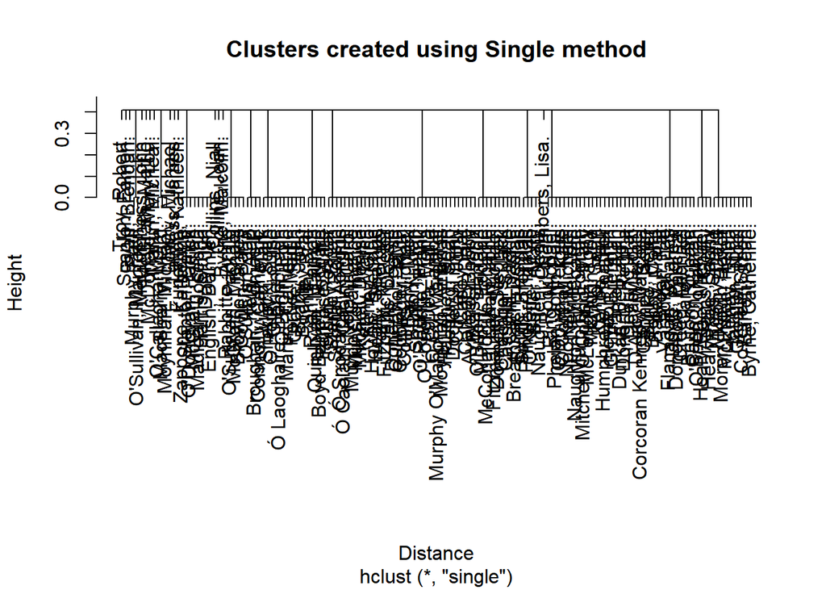

```r
# Method = 2 corresponds to Simple Matching method
dist1<-dist.binary(votingdata,method = 2)


## Hierarchical CLustering with Single Method
votingSingle2<-hclust(dist1,method = "single")

plot(votingSingle2,xlab = "Distance",ylab = "Height", main = "Clusters created using Single method")
```

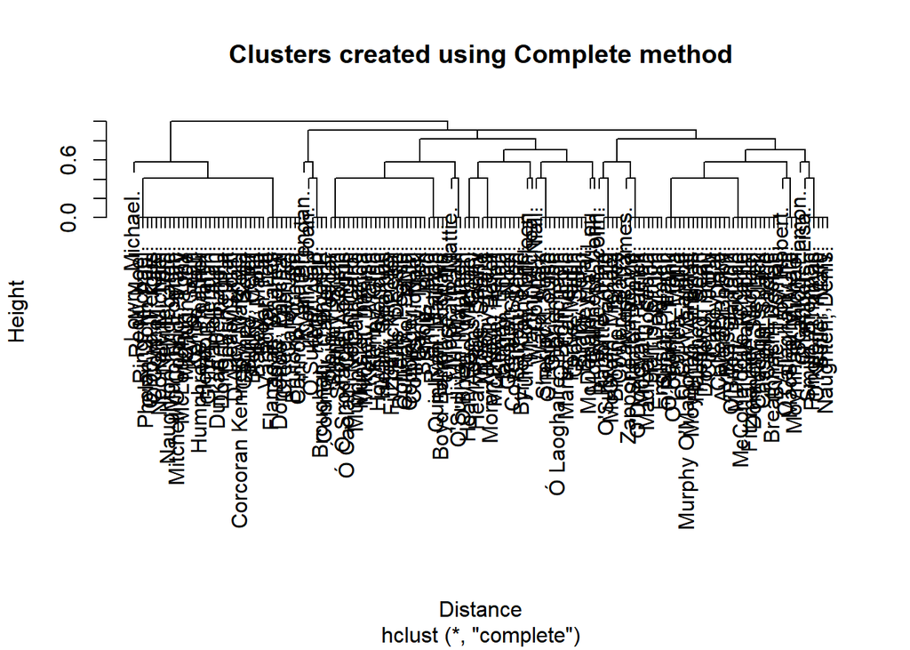

```r
# Hierarchical CLustering with Complete Method
votingcomplete2<-hclust(dist1,method = "complete")

plot(votingcomplete2,xlab = "Distance",ylab = "Height", main = "Clusters created using Complete method")
```

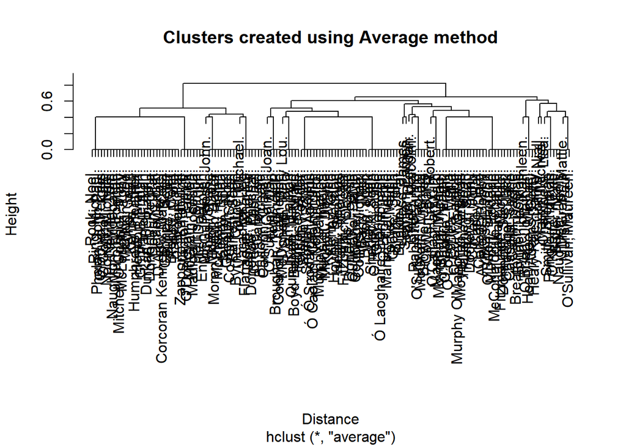

```r
# Hierarchical CLustering with Average Method
votingavg2<-hclust(dist1,method = "average")

plot(votingavg2,xlab = "Distance",ylab = "Height", main = "Clusters created using Average method")
```

From the plots, the cluster constructed by ‘Average’ method visualizes the distance better when compared with other types of methods. We can clearly see that we can split the data into 2 clusters.

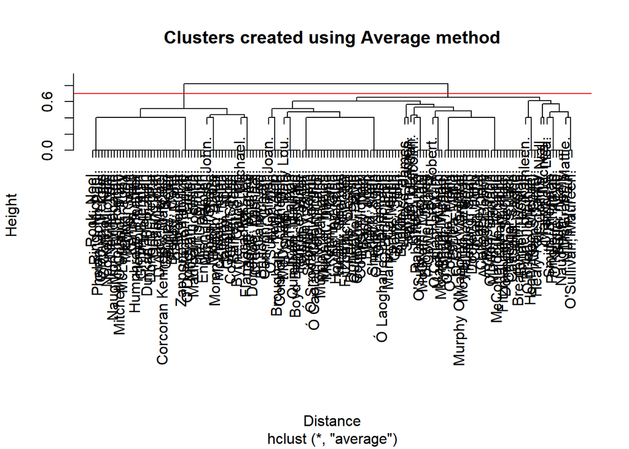

```r
plot(votingavg2,xlab = "Distance",ylab = "Height", main = "Clusters created using Average method")
abline(h=0.7,col="red")
```

From the plot, we can be predict the number of clusters to be 2.

1 (b) Use the poLCA function in R to cluster the TDs based on their voting data. Detail any decisions you make in the process. How many clusters of TDs do you think are present now? On what basis did you make this decision? Include any output or plots which you use to motivate your decision

Polytomous Latent Class Analysis(poLCA) is a clustering method in Latent Class Analysis(LCA) package.It is a type of clustering method which is used for clustering the dataset when the variables are categorical in nature. We will build models with different classes using poLCA and compare which is the better one using BIC values.

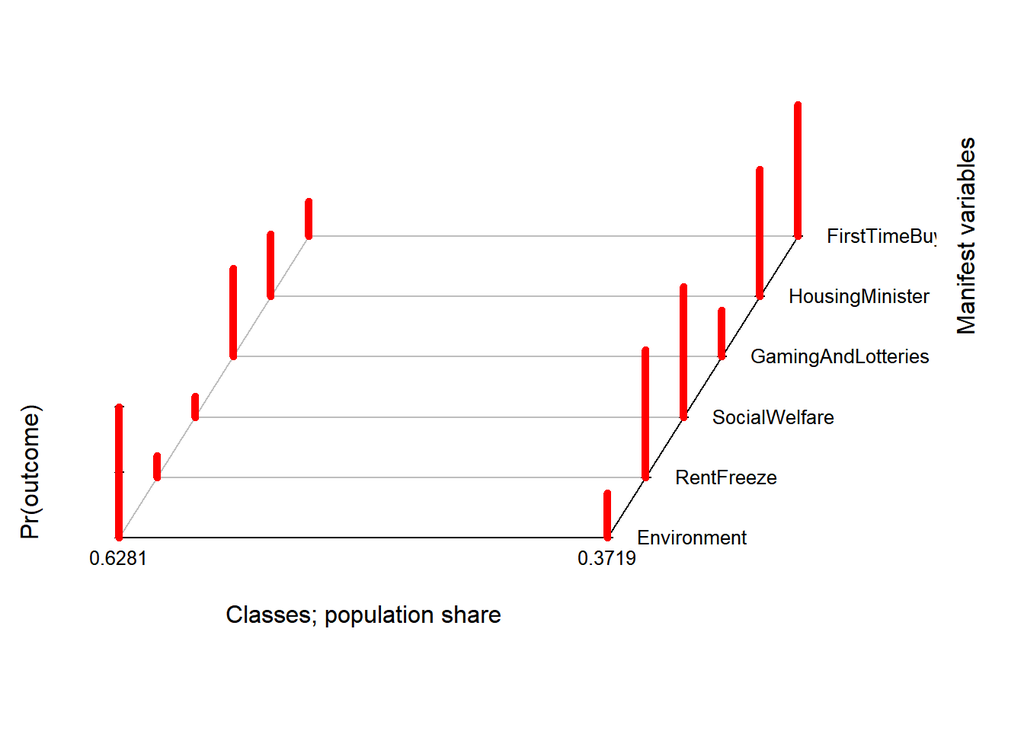

```r
f<-cbind(Environment,RentFreeze,SocialWelfare,GamingAndLotteries,HousingMinister,FirstTimeBuyers)~1

# Three models are developed based on the classes and their BIC are compared to summarize the optimal model.Parameter Verbose can be used to restrict the funtion to print all the output to the screen.
poLCA2<-poLCA(f,data = votingdata +1,nclass = 2,graphs = TRUE,na.rm = TRUE,maxiter = 1000,verbose = FALSE)
```

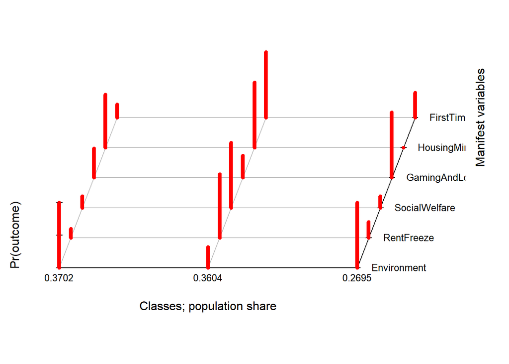

```r
poLCA3<-poLCA(f,data = votingdata +1,nclass = 3,graphs = TRUE,na.rm = TRUE,maxiter = 1000,verbose = FALSE)
```

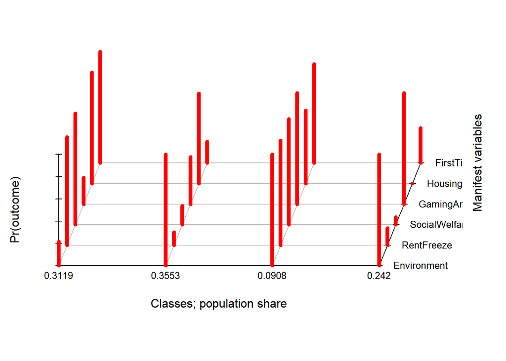

```r
poLCA4<-poLCA(f,data = votingdata +1,nclass = 4,graphs = TRUE,na.rm = TRUE,maxiter = 1000,verbose = FALSE)
```

```r
#The AIC and BIC can be compared and the optimal model can be concluded.
cat("The AIC and BIC values of model with class 2 is: ",poLCA2$aic, " & ", poLCA2$bic," respectively")
```

```
## The AIC and BIC values of model with class 2 is:  950.0332  &  989.6813  respectively
```

```r
cat("The AIC and BIC values of model with class 3 is: ",poLCA3$aic, " & ", poLCA3$bic," respectively")
```

```
## The AIC and BIC values of model with class 3 is:  937.0493  &  998.0465  respectively
```

```r
cat("The AIC and BIC values of model with class 4 is: ",poLCA4$aic, " & ", poLCA4$bic," respectively")
```

```
## The AIC and BIC values of model with class 4 is:  933.0333  &  1015.379  respectively
```

```r
# Since the BIC value of class =2 is lower compared with other class 3 and 4, we can see that the class 2 is optimal.
```

1 (c) Compare the clustering from the polytomous analysis 1(b) to the clustering obtained by cutting the dendrogram you view as optimal from (a).

The hierarchical clustering using ‘Average’ method shows that the data can be split into two clusters. This is shown by cutting the tree at 0.7 height. This will show the dendogram with two clusters.

Also from the Polytomous analysis, we come into conclusion that the model with class = 2 is an optimal model. These two data can be compared and the clustering can be confirmed using “classAgreement”.

```r
#The dendogram is cut using cutree and is used for comparing with polytomous analysis.
votinghcl2<-cutree(votingavg2, k = 2)

#library(e1071)

#The output of the cutree is stored in votinghcl2 which is compared with the vector of predicted class memberships and then used for external validation.
tab<-table(votinghcl2,poLCA2$predclass)
classAgreement(tab)
```

```
## $diag
## [1] 0.9935897
##
## $kappa
## [1] 0.9861259
##
## $rand
## [1] 0.9871795
##
## $crand
## [1] 0.9742328
```

The output of external validation with adjusted RandIndex value as 0.97 shows that the cluster values derived from both the methods is optimal.

1 (d) Write a report outlining your research and conclusions, based on your LCA analysis.

**Voting patterns in the 32nd Dail Eireann**

Ireland is a parliamentary democracy and consists of the President and two houses, Dail Eireann (House of Representatives) and Seanad Eireann (the Senate). The members of Dail Eireann, called Teachtai Dala (TDs), are directly elected by the people.During the 5th session of the 32nd Dail Eireann, the votes of TDs are recorded in a dataset and is used for analyse the voting pattern of the TDs.

The voting patten of the TDs can be analyzed by clustering the TDs and splitting the groups with similar voting patterns. This clustering can be carried out using Latent Class Analysis (LCA) approach and votes pattern can be derived using Polytomous Analysis.

#### Latent Class Analysis approach

Latent Class Analysis(LCA) is a statistical technique that can be used for analysis of multivariate categorical data. It analyzes the clustering the observations in a multi-way tables of these categorical variables. LCA is part of “poLCA” package in R and it has several functions that can be used for clustering and calculating the posterior and likelihood probabilities of the variables.

One such function of LCA is ‘poLCA’.Polytomous Latent Class Analysis(poLCA) is a function in LCA package and is uded in predicting the latent class memberships by one or more covariates.poLCA estimates the latent class model by maximizing the log-likelihood function using the Expectation-Maximization (EM) algorithm. It estimates the standard errors of the estimated class-conditional response probabilities and mixing parameters.It also calculates the parsimony measures while estimating the latent class model. These parameters include Akaike information criterion (AIC) and Bayesian information criterion (BIC),which are used for analyzing goodness of fit.Preferred models are those that minimize values of the BIC and/or AIC.The BIC will usually be more appropriate for basic latent class models because of their relative simplicity.

#### Modelling the dataset

The voting pattern of 32nd Dail Eireann can be estimated using this polytomous analysis, by fitting the models with serveral classes and arriving to an optimal class. The model is fit using poLCA function with variables formula,data,nclass,graphs. Data variable will have the dataset assigned and nclass represents the number of latent classes to assume in the model. Variable graphs depicts the probability of variables with respect to number of latent classes.

```
## The AIC and BIC values of model with class 2 is:  950.0332  &  989.6813  respectively.
##  The AIC and BIC values of model with class 3 is:  937.0493  &  998.0465  respectively.
##  The AIC and BIC values of model with class 4 is:  933.0333  &  1015.379  respectively.
```

From the values,we can see that the BIC value of class =2 is lower compared with other class 3 and 4, so, the model with class 2 gives an optimal result. So, we can use the latent class model with nclass as 2 for estimating the voting pattern of TDs and examining the membership of the clusters.

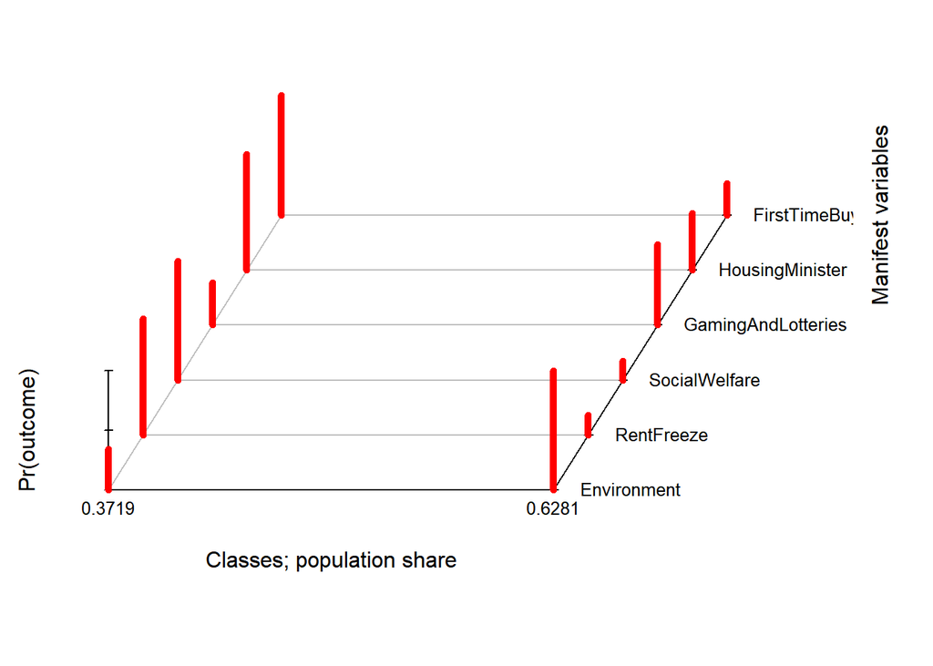

```
## Conditional item response (column) probabilities,
##  by outcome variable, for each class (row)
##
## $Environment
##           Pr(1) Pr(2)
## class 1:  0.655 0.345
## class 2:  0.000 1.000
##
## $RentFreeze
##            Pr(1)  Pr(2)
## class 1:  0.0261 0.9739
## class 2:  0.8316 0.1684
##
## $SocialWelfare
##            Pr(1)  Pr(2)
## class 1:  0.0000 1.0000
## class 2:  0.8369 0.1631
##
## $GamingAndLotteries
##            Pr(1)  Pr(2)
## class 1:  0.6429 0.3571
## class 2:  0.3235 0.6765
##
## $HousingMinister
##            Pr(1)  Pr(2)
## class 1:  0.0330 0.9670
## class 2:  0.5214 0.4786
##
## $FirstTimeBuyers
##            Pr(1)  Pr(2)
## class 1:  0.0000 1.0000
## class 2:  0.7348 0.2652
##
## Estimated class population shares
##  0.3719 0.6281
##
## Predicted class memberships (by modal posterior prob.)
##  0.359 0.641
##
## =========================================================
## Fit for 2 latent classes:
## =========================================================
## number of observations: 156
## number of estimated parameters: 13
## residual degrees of freedom: 50
## maximum log-likelihood: -462.0166
##
## AIC(2): 950.0332
## BIC(2): 989.6813
## G^2(2): 58.95794 (Likelihood ratio/deviance statistic)
## X^2(2): 67.89298 (Chi-square goodness of fit)
##
```

The summary of model 2 shows the probability of each class or cluster for its respective categorical variable. From the graph, we can see that the predicted class memberships is 0.641 and 0.359. We can compare the predicted class of each categorical variable with the political affiliation of each TD and then interpret the voting pattern of each group.

```
##
##     AAA-PBP FF FG Green I4C Ind Lab SD SF
##   1       0  0 48     0   1   7   0  0  0
##   2       6 43  1     3   2  11   7  3 24
```

#### Appendix

```r
#A formula expression of the form response ~ predictors
f<-cbind(Environment,RentFreeze,SocialWelfare,GamingAndLotteries,HousingMinister,FirstTimeBuyers)~1

# Three models are developed based on the classes and their BIC are compared to summarize the optimal model.Parameter Verbose can be used to restrict the funtion to print all the output to the screen.
poLCA2<-poLCA(f,data = votingdata +1,nclass = 2,graphs = FALSE,na.rm = TRUE,maxiter = 1000,verbose = FALSE)
poLCA3<-poLCA(f,data = votingdata +1,nclass = 3,graphs = FALSE,na.rm = TRUE,maxiter = 1000,verbose = FALSE)
poLCA4<-poLCA(f,data = votingdata +1,nclass = 4,graphs = FALSE,na.rm = TRUE,maxiter = 1000,verbose = FALSE)

#The AIC and BIC can be compared and the optimal model can be concluded.
cat("The AIC and BIC values of model with class 2 is: ",poLCA2$aic, " & ", poLCA2$bic," respectively. \n","The AIC and BIC values of model with class 3 is: ",poLCA3$aic, " & ", poLCA3$bic," respectively.\n","The AIC and BIC values of model with class 4 is: ",poLCA4$aic, " & ", poLCA4$bic," respectively.")

#The party data is added and is used for comparing the class data
TDnames<-read.csv("TDs_names_parties.csv",header = T)

#Predicted class membership and the party data is compared to check the number of TDs added to each class.
table(poLCA2$predclass,TDnames$Party)
```

#### Question 2

A sample of 30 wild growing and ???owering Hyptis suaveolens plants were collected in El Salvador, and the concentrations of 7 terpenes (sabinene, ??-pinene, 1.8-cineole, ??-terpinene, fenchone, ??-terpinolene and fenchol) were measured (data Hyptis.csv available in Brightspace). Interest lies in uncovering di???erent chemotypes of plant (if any) using the terpene measures. The geographical region from which each plant was collected was also recorded, either north, south or east. For the eastern plants, a distinction was made whether the plants grew at low or high altitude.

The Hyptis dataset is loaded to a data frame ‘hyptisdata’. This data frame will be used for applying various Multidimensional scaling methods.

```r
hyptisdata<-read.csv("Hyptis.csv",header = T)
```

2 (a) Apply classical metric scaling to the data, explaining any decisions you make in the process. Choose a suitable number of dimensions required to represent the resulting con???guration. Explain, using a graphic to support your argument, your reasoning behind your choice of the required number of dimensions. Plot the two dimensional con???guration resulting from the application of classical metric scaling. Label each point in your plot using the geographical location of each plant.

For applying Classical Metric Scaling,we have to first calculate the dissimilarity matrix and use cmdscale for calculating the eigen values and then use it determining the dimensions.

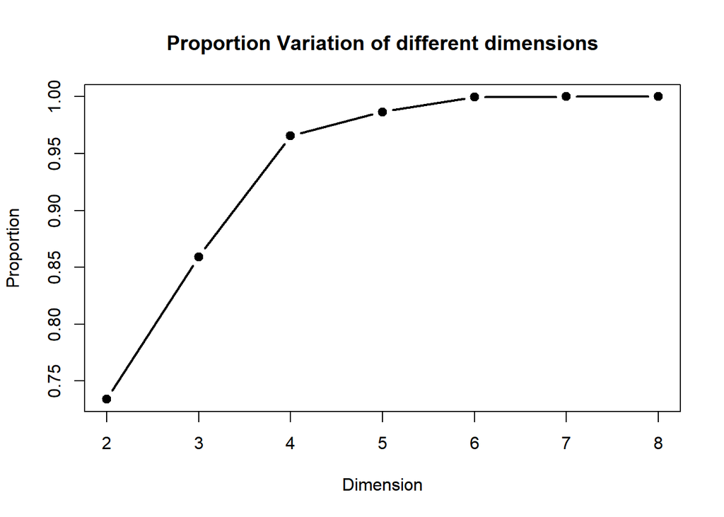

```r
# Computing the Dissimilarity Matrix
D<- dist(hyptisdata[,1:7], method="euclidean")

#metric classical scaling for q=2
mds2<-cmdscale(D,k=2,eig = TRUE)

#proportion variation for storing several dimensions
variation <- c()

for(i in 2:8){
  variation <- c(variation,sum(abs(mds2$eig[1:i]))/sum(abs(mds2$eig)))
  }

#plotting of the variance with respect to their dimensions
plot(2:8,variation,main="Proportion Variation of different dimensions", xlab="Dimension", ylab="Proportion", type="b",lwd=2, pch=19)
```

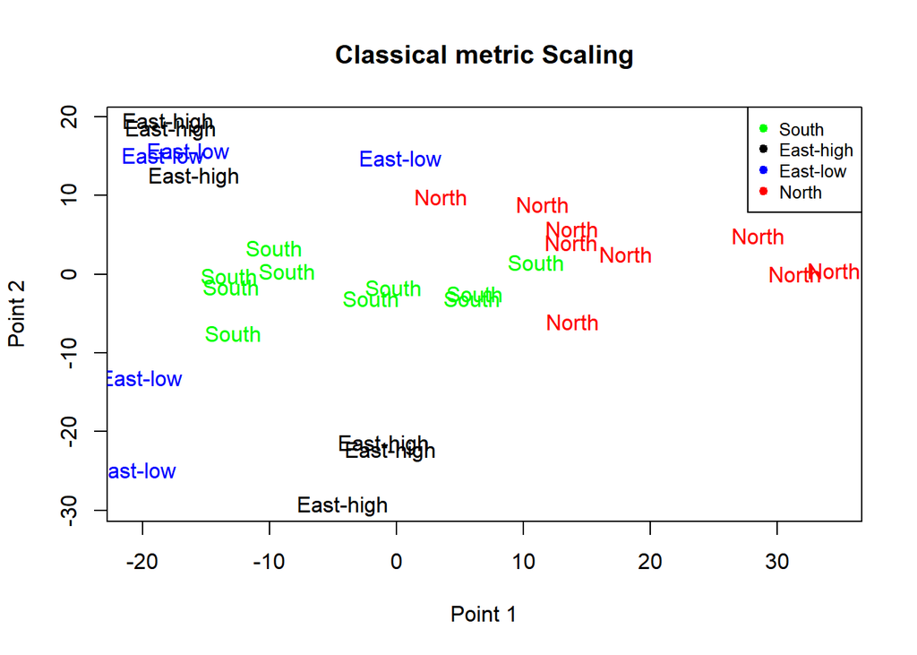

```r
plot(mds2$points[,1],mds2$points[,2],type = "n",xlab = "Point 1",ylab = "Point 2",main="Classical metric Scaling")
text(mds2$points[,1],mds2$points[,2],hyptisdata[,8],cex=1,col = c("black","blue","red","green")[hyptisdata[,8]])

legend("topright", legend=unique(hyptisdata[,8]),
       col=c("green","black","blue","red"), pch=19, cex=0.8)
```

2 (b) Apply Sammon’s metric least squares scaling and Kruskal’s non-metric scaling to the data. Overlay the resulting two dimensional con???gurations on your plot of the classical scaling con???guration. Label each point using the observation number of the associated plant.

The Sammon’s metric least squares scaling and Kruskal’s non-metric scaling can be applied using the ‘Sammon’ function and ‘isoMDS’ function respectively of MASS package.

```r
#Sammon stress variable
sammonstress<-c()

#Kruskal stress variable
kruskalstress<-c()
k<-8
for(i in 1:k){
  sammonstress<-c(sammonstress,sammon(D,k=i)$stress)
  kruskalstress<-c(kruskalstress,isoMDS(D,k=i)$stress)
}
```

[output not shown]

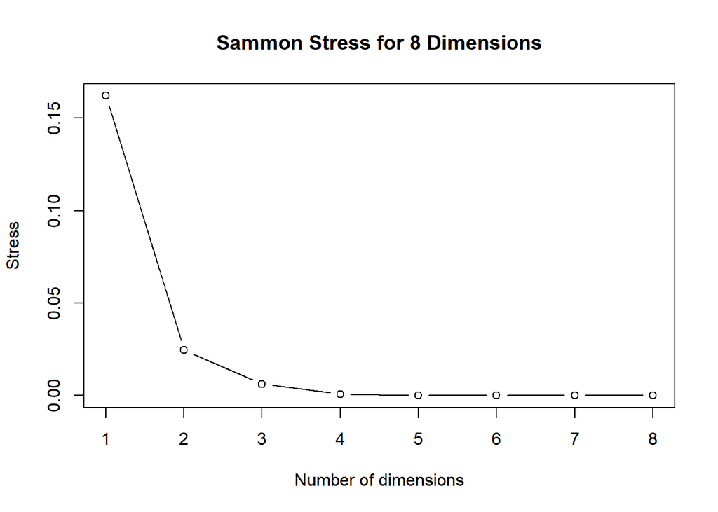

```r
#Plotting the stress of Sammon metric least squares scaling
plot(x=c(1:k),y=sammonstress,type = "b", xaxp=c(1,k, k-1), ylab="Stress", xlab="Number of dimensions",main = "Sammon Stress for 8 Dimensions")
```

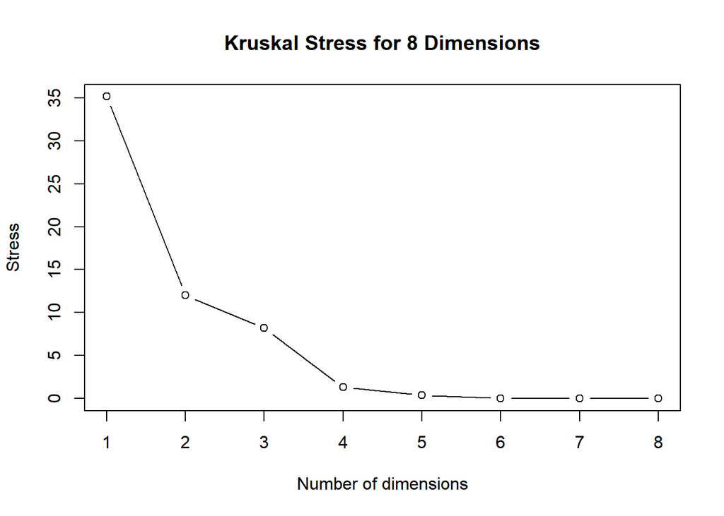

```r
#Plotting the stress of Kruskal's non-metric scaling
plot(x=c(1:k),y=kruskalstress,type = "b", xaxp=c(1,k, k-1), ylab="Stress", xlab="Number of dimensions",main = "Kruskal Stress for 8 Dimensions")
```

From the plot we can see that both the scaling methods points a steep reduction in stress at q = 2,ie, in two dimension. The stress gradually decreases after this dimension. So, we can use the dimension as 2 and apply the scaling methods on the data.

```r
# Applying Sammon and Kruskal function to the data with q=2
Sammon2<-sammon(D,k=2)
```

```
## Initial stress        : 0.06787
## stress after  10 iters: 0.02647, magic = 0.500
## stress after  20 iters: 0.02612, magic = 0.500
## stress after  30 iters: 0.02546, magic = 0.500
## stress after  40 iters: 0.02464, magic = 0.500
## stress after  50 iters: 0.02446, magic = 0.500
## stress after  60 iters: 0.02445, magic = 0.500
```

```r
Kruskal2<-isoMDS(D,k=2)
```

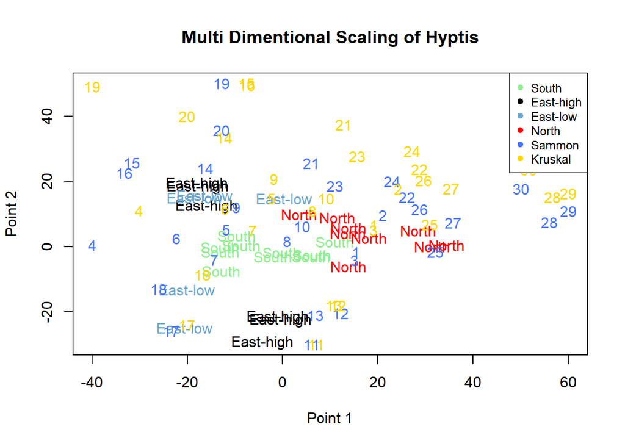

```r
# The calculated values are then plotted on the plot of classical scaling configuration

plot(mds2$points[,1],mds2$points[,2],type = "n",xlim = c(-40,60),ylim = c(-30,50), xlab = "Point 1",ylab = "Point 2",main="Multi Dimentional Scaling of Hyptis")
text(mds2$points[,1],mds2$points[,2],hyptisdata[,8],cex=1,col = c("black","skyblue3","red","palegreen2")[hyptisdata[,8]])
par(new=TRUE,col.axis = "transparent")
plot(Sammon2$points[,1],Sammon2$points[,2],type = "n",xlab = "",ylab = "",axes=FALSE)
text(Sammon2$points[,1],Sammon2$points[,2],row.names(hyptisdata),cex=1,col ="royalblue1")
par(new=TRUE,col.axis = "transparent")
plot(Kruskal2$points[,1],Kruskal2$points[,2],type = "n",xlab = "",ylab = "",axes=FALSE)
text(Kruskal2$points[,1],Kruskal2$points[,2],row.names(hyptisdata),cex=1,col ="gold1")
legend("topright", legend=c(as.character(unique(hyptisdata[,8])),"Sammon","Kruskal"),
       col=c("palegreen2","black","skyblue3","red","royalblue1","gold1"), pch=19, cex=0.8)
```

2 (c) Use Procrustes analysis to match the three resulting con???gurations of the plants. Which con???gurations match best? Suggest a reason for your conclusion

Procrustes Analysis is a technique that matches one configuration to another and produces a measure of the match.

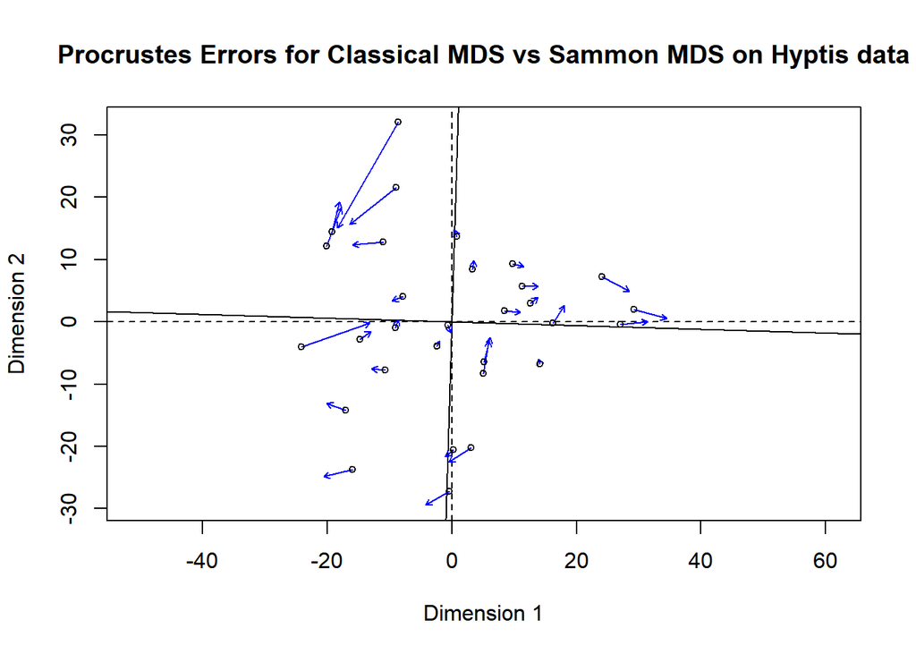

```r
# Matching the configurations of Classical,Sammon and Kruskal scaling method.
proc12<-procrustes(mds2$points,Sammon2$points)
proc23<-procrustes(Sammon2$points,Kruskal2$points)
proc31<-procrustes(Kruskal2$points,mds2$points)

# Plotting each match with procrustes error between the two configuration
plot(proc12,xlab = "Dimension 1",ylab = "Dimension 2", main = "Procrustes Errors for Classical MDS vs Sammon MDS on Hyptis data")
```

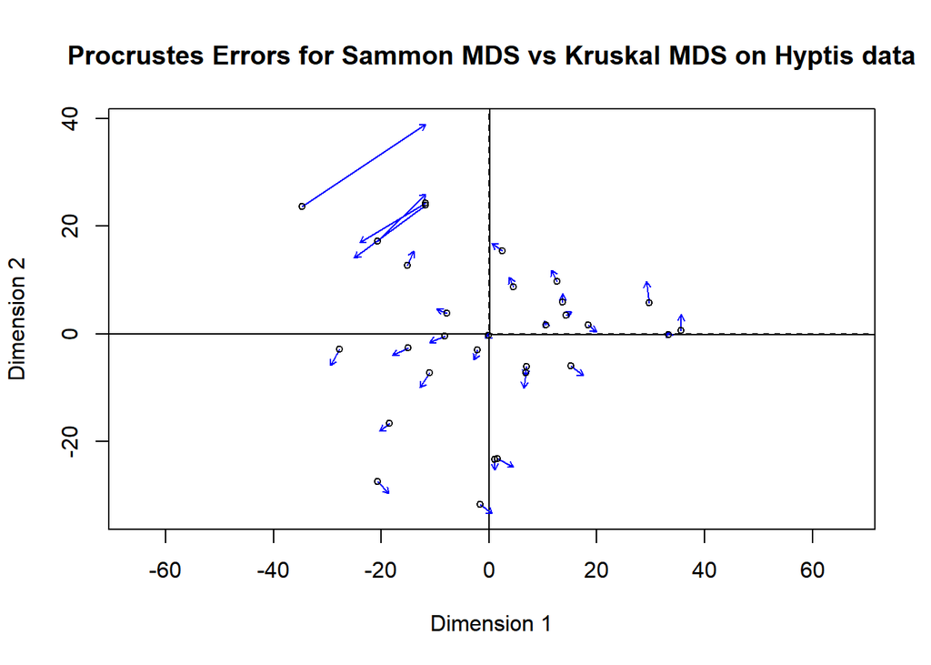

```r
plot(proc23,xlab = "Dimension 1",ylab = "Dimension 2", main = "Procrustes Errors for Sammon MDS vs Kruskal MDS on Hyptis data")
```

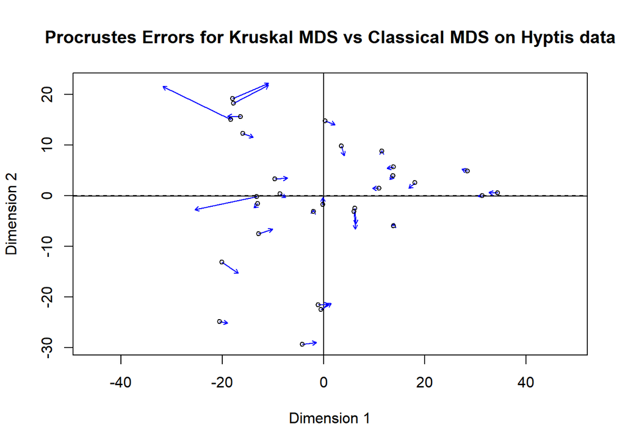

```r
plot(proc31,xlab = "Dimension 1",ylab = "Dimension 2", main = "Procrustes Errors for Kruskal MDS vs Classical MDS on Hyptis data")
```

From the above plots, we see that the points in all three configurations has procrustes Errors in them. But Kruskal configuration has less procrustes error compared with other plots. So it can be considered as a good configuration. We can confirm it by verifying the Residual erros aswell.

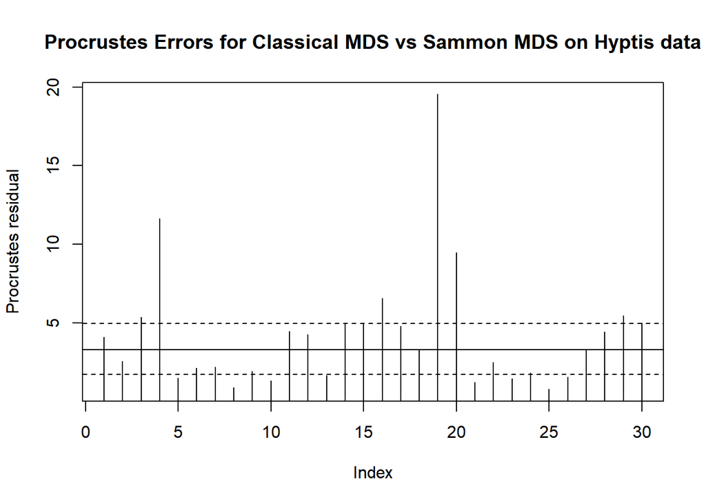

```r
# Procrustes residual errors
plot(proc12,kind = 2, main = "Procrustes Errors for Classical MDS vs Sammon MDS on Hyptis data")
```

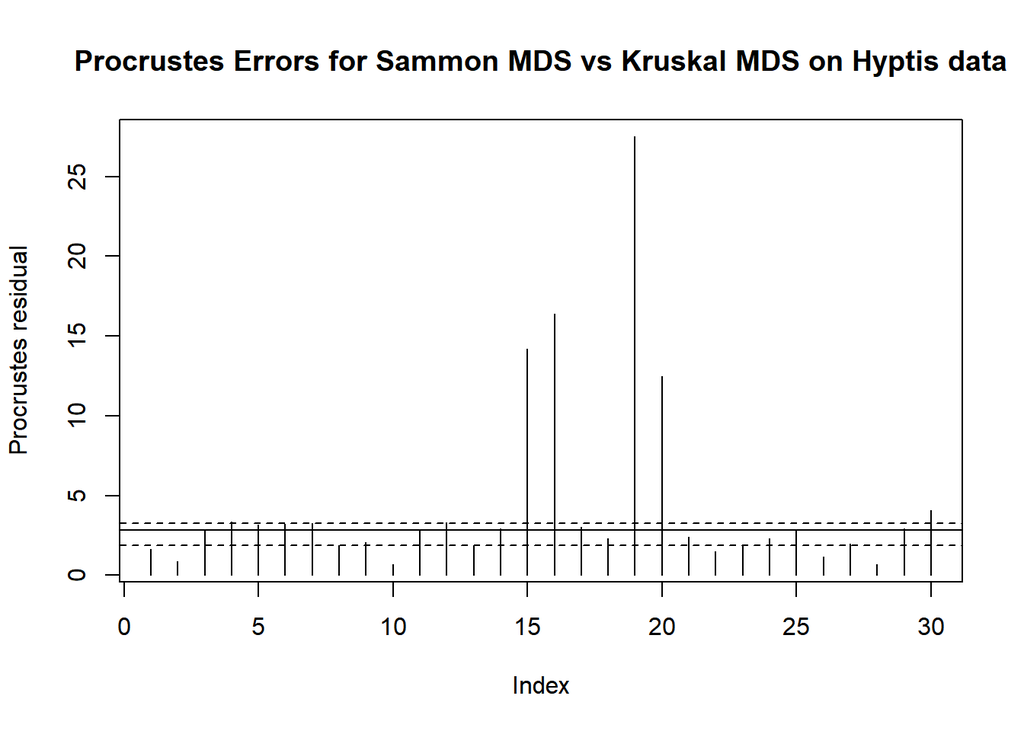

```r
plot(proc23,kind = 2, main = "Procrustes Errors for Sammon MDS vs Kruskal MDS on Hyptis data")
```

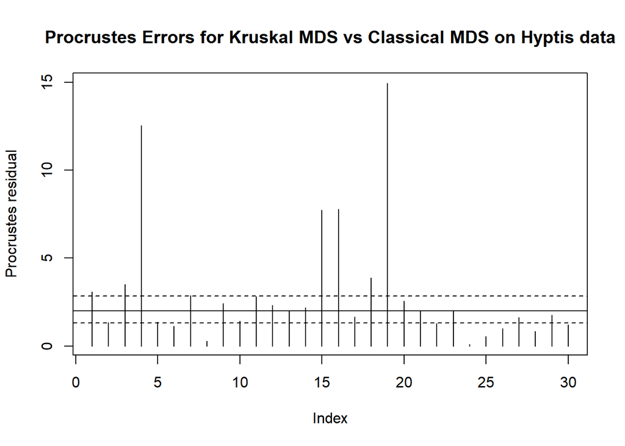

```r
plot(proc31,kind = 2, main = "Procrustes Errors for Kruskal MDS vs Classical MDS on Hyptis data")
```

From the Procrustes Residual plots, we can see that the Kruskal versus Classical MDS plot has less Procrustes residual error compared with other plots. From this, we can suggest that Kruskal MDS configuration fits better compared with the other two configurations.

2 (d) Perform model-based clustering on these data. How many clusters are chosen as optimal? Explain how you arrived at your answer.

The Model Based Clustering can be done using mclust function.

```r
res1<-Mclust(hyptisdata[,1:7],G=1:6)
summ<-summary(res1)

res1$BIC
```

```
## Bayesian Information Criterion (BIC):
##         EII       VII       EEI       VEI       EVI       VVI       EEE
## 1 -1534.671 -1534.671 -1430.731 -1430.731 -1430.731 -1430.731 -1363.418
## 2 -1516.394 -1492.713 -1416.033 -1395.465 -1398.577 -1387.067 -1378.315
## 3 -1490.860 -1463.129 -1404.612 -1385.553 -1392.777 -1365.842 -1381.151
## 4 -1479.260 -1460.120 -1377.685 -1374.947        NA        NA -1364.810
## 5 -1475.484 -1435.108 -1391.356 -1355.610        NA        NA -1350.639
## 6 -1458.831 -1400.271 -1387.737 -1349.284        NA        NA -1339.974
##         EVE       VEE       VVE       EEV       VEV       EVV       VVV
## 1 -1363.418 -1363.418 -1363.418 -1363.418 -1363.418 -1363.418 -1363.418
## 2 -1348.799 -1373.693 -1349.190 -1406.801 -1391.472 -1400.549 -1377.730
## 3        NA        NA        NA -1422.666 -1400.862        NA        NA
## 4        NA        NA        NA -1286.380 -1400.790        NA        NA
## 5        NA        NA        NA -1273.187 -1320.322        NA        NA
## 6        NA        NA        NA -1302.723 -1175.816        NA        NA
##
## Top 3 models based on the BIC criterion:
##     VEV,6     EEV,5     EEV,4
## -1175.816 -1273.187 -1286.380
```

From the BIC values, we can see that G=6 is the optimal group(cluster) in the function. We can confirm this by plotting the values to a graph.

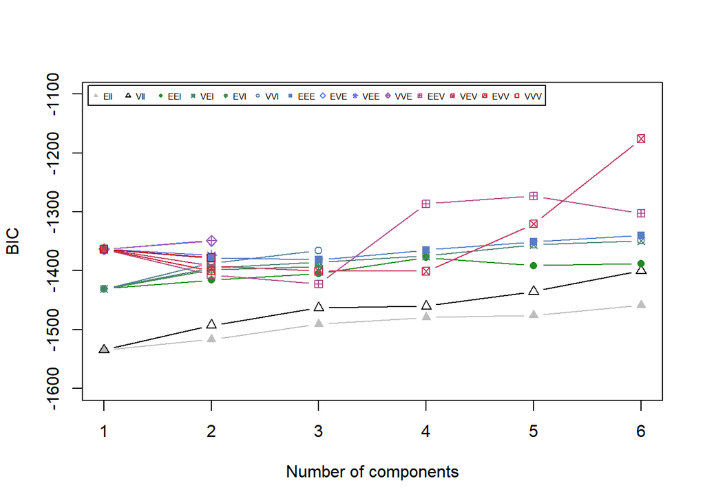

```r
plot(res1,what = "BIC",legendArgs=list(x="topleft",cex=0.5,horiz=T),ylim = c(-1600,-1100))
```

```r
#Cross Tabulation
table(hyptisdata[,8],summ$classification)
```

```
##
##             1 2 3 4 5 6
##   East-high 0 0 3 3 0 0
##   East-low  2 1 0 0 2 0
##   North     0 6 0 0 0 3
##   South     8 1 1 0 0 0
```

```r
#Calculating the adjusted Rand Index
adjustedRandIndex(hyptisdata[,8],summ$classification)
```

```
## [1] 0.4403259
```

From the cross tabulation and adjusted Rand Index value, we can see that the data points are fairly clustered and has a Adjusted Rand Index value as 0.44. Therefore, the optimal clusters for this dataset is 6.